# Análisis de la base Victimas del Accionar Represivo Ilegal

Ariana Bardauil - Leonardo Paoli

2022-09-29

## 0.1 Introducción

Las personas desaparecidas por el terrorismo de Estado en Argentina son víctimas del crimen de desaparición forzada antes, durante y después de la última dictadura cívico-militar que hubo en Argentina, autodenominada Proceso de Reorganización Nacional, entre 1976 y 1983. Encerradas en centros clandestinos de detención, eran sometidas a torturas y en muchos casos asesinadas. Las primeras desapariciones y los primeros centros clandestinos de detención se instalaron en 1975, durante el gobierno constitucional de María Estela Martínez de Perón, y continuaron hasta 1984, durante el gobierno constitucional de Raúl Alfonsín.

Los datos son recopilados en el paquete “*presentes*” pone a disposición información oficial sobre las víctimas del terrorismo de estado. El paquete fue desarrollado por **Diego Kozlowski, Demian Zayat, H. Antonio Vazquez Brust.** Las variables que tiene en cuenta son:

La fuente de datos que alimenta este paquete es del [registro unificado del listado de Víctimas del accionar represivo ilegal del Estado argentino entre 1966 y 1983](http://datos.jus.gob.ar/dataset/registro-unificado-de-victimas-del-terrorismo-de-estado-ruvte), del [Informe de Investigación RUVTE-ILID](https://www.argentina.gob.ar/derechoshumanos/ANM/ruvte/informe) y la [base de datos del parque de la memoria](http://basededatos.parquedelamemoria.org.ar/registros/)

En nuestro caso utilizaremos el dataset de **victimas_accionar_represivo_ilegal** que contiene el listado de víctimas con denuncia formal del **Registro Unificado de Víctimas del Terrorismo de Estado (RUVTE).** Esta base, incluye 8753 registros al día de la fecha, con datos sobre el año de la denuncia, la tipificación del RUVTE, datos personales, edad al momento del hecho, fecha de la detención o asesinato, lugar de la detención o secuestro, lugar de hallazgo de los restos, provincia y país de nacimiento, y si tiene fotografía, entre otros.

## 0.2 Exploración de los datos

Observamos las variables que contiene nuestra base de datos

```r
victimas <- victimas %>%
  clean_names() %>%
  remove_empty(which = c("rows", "cols")) %>%
  glimpse()
```

```
## Rows: 8,753
## Columns: 21
## $ id_unico_ruvte                       <chr> "5389", "87", "11788", "9907", "8…
## $ anio_denuncia                        <dbl> 1984, 1984, 1984, 1984, 1984, 198…
## $ tipificacion_ruvte                   <chr> "DESAPARICION FORZADA", "DESAPARI…
## $ apellido_paterno_nombres             <chr> "ABACHIAN  JUAN CARLOS", "ABAD  A…
## $ apellido_materno                     <chr> "BEDROSSIAN", "SCARLATA", "CORONE…
## $ apellido_casada                      <chr> NA, "PERUCCA", NA, NA, NA, NA, NA…
## $ edad_al_momento_del_hecho            <chr> "26 años", "24 años", "21 años", …
## $ edad_al_momento_del_hecho_numerico   <dbl> 26, 24, 21, 25, 23, 54, 23, 25, 2…
## $ documentos                           <chr> "LE 8293245", "LC 10048122", "DNI…
## $ anio_nacimiento                      <chr> "1950", "1951", "1954", "1951", "…
## $ provincia_nacimiento                 <chr> "BUENOS AIRES", "MENDOZA", "TUCUM…
## $ pais_nacimiento                      <chr> "ARGENTINA", "ARGENTINA", "ARGENT…
## $ nacionalidad                         <chr> "ARGENTINA", "ARGENTINA", "ARGENT…
## $ embarazo                             <chr> NA, NA, NA, NA, NA, NA, NA, NA, N…
## $ fecha_detencion_secuestro            <chr> "26/12/1976", "15/08/1976", "NOV/…
## $ lugar_detencion_secuestro            <chr> "LA PLATA  BUENOS AIRES", "CORDOB…
## $ fecha_asesinato_o_hallazgo_de_restos <chr> NA, NA, NA, "21/10/1976", NA, NA,…
## $ lugar_asesinato_o_hallazgo_de_restos <chr> NA, NA, NA, "GRAL. MANSILLA (BART…
## $ fotografia                           <chr> "Sí", "Sí", "No", "No", "Sí", "No…
## $ provincia_nacimiento_indec_id        <chr> "06", "50", "90", "06", "02", "90…
## $ pais_nacimiento_indec_id             <chr> "ARG", "ARG", "ARG", "ARG", "ARG"…
```

Las variables son:

| Variable | Descripción |
| --- | --- |
| `id_unico_ruvte` | Id del Registro Unificado de Víctimas del Terrorismo de Estado |
| `anio_denuncia` | Año de la denuncia |
| `tipificacion_ruvte` | Si fue asesinato o desaparición |
| `apellido_paterno_nombres` | Apellido paterno |
| `apellido_materno` | Apellido Materno |
| `apellido_casada` | Apellido de Casada |
| `edad_al_momento_del_hecho` | Edad al momento del hecho |
| `documentos` | DNI o Libreta Cívica |
| `anio_nacimiento` | Año de nacimiento |
| `provincia_nacimiento` | Provincia de Nacimiento |
| `pais_nacimiento` | Pais de nacimiento |
| `nacionalidad` | Nacionalidad |
| `embarazo` | ¿Estaba embarazada? |
| `fecha_detencion_secuestro` | Fecha de detención/secuestro |
| `lugar_detencion_secuestro` | Lugar de detención/secuestro |
| `fecha_asesinato_o_hallazgo_de_restos` | Fecha de asesinato o fecha de hallazgo de restos |
| `lugar_asesinato_o_hallazgo_de_restos` | Lugar de asesinato o lugar de hallazgo de restos |
| `fotografia` | ¿Hay fotografía? |
| `provincia_nacimiento_indec_id` | Provincia de nacimiento según INDEC |
| `pais_nacimiento_indec_id` | Pais de Nacimiento según INDEC |

```r
#Pasamos a factor las posibles variables de clasificacion
victimas <- victimas %>%
  mutate(anio_denuncia = as.factor(anio_denuncia),
         anio_nacimiento = as.factor(anio_nacimiento),
         provincia_nacimiento = as.factor(provincia_nacimiento),
         embarazo = as.factor(embarazo),
         pais_nacimiento = as.factor(pais_nacimiento),
         fotografia =as.factor(fotografia)
         )

#Creamos una variable sobre si es argentino o extranjero

victimas <- victimas %>%
  mutate(pais_arg = if_else(pais_nacimiento == 'ARGENTINA',true = 'ARGENTINA', false = if_else(pais_nacimiento %in% c('URUGUAY','PARAGUAY','CHILE','PERU','BOLIVIA','BRASIL','COLOMBIA','CUBA','VENEZUELA','MEXICO','GUATEMALA'),true = "LATINOAMERICA",false = 'OTROS')))

columna <- c("pais_nacimiento","pais_arg","provincia_nacimiento","embarazo","tipificacion_ruvte","anio_denuncia")

#creamos tablas de recuentos
contabilizar <- function(columna) {
  victimas %>%
    group_by(across(columna)) %>%
    summarise(N=n()) %>%
    arrange(desc(N))
}

tablas <- purrr::map(columna, contabilizar)
```

## 0.3 Algunos Análisis

### 0.3.1 Año de denuncia

```r
#analisis de las victimas por año
gt::gt(tablas[[6]], caption = "Tabla 1: Victimas de la represión ilegal por año de denuncia")
```

Tabla 1: Victimas de la represión ilegal por año de denuncia

| anio_denuncia | N |
| --- | --- |
| 1984 | 6756 |
| 1995 | 572 |
| 1999 | 134 |
| 2000 | 133 |
| 2004 | 128 |
| 1996 | 122 |
| 2013 | 121 |
| 1997 | 89 |
| 2006 | 78 |
| 1998 | 74 |
| 2005 | 72 |
| 1988 | 64 |
| 1987 | 44 |
| 2014 | 38 |
| 1989 | 37 |
| 2015 | 35 |
| 2010 | 33 |
| 2012 | 33 |
| 2007 | 32 |
| 2003 | 24 |
| 2009 | 22 |
| 2001 | 18 |
| 2008 | 18 |
| 2002 | 17 |
| 2011 | 17 |
| 2016 | 10 |
| 1994 | 9 |
| 1985 | 6 |
| 1986 | 5 |
| 1990 | 5 |
| 1992 | 3 |
| 1993 | 3 |
| 1991 | 1 |

La mayoría de las denuncias efectuadas fue en el año 1984. Esto es debido a que, con la vuelta a la democracia en 1983, el presidente Raúl Alfonsín sancionó el Decreto N.º 158/83 que ordenó someter a juicio sumario a nueve militares de las tres armas que integraron las Juntas que dirigieron el país desde el golpe militar del 24 de marzo de 1976 hasta la Guerra de las Malvinas en 1982. Resulta importante destacar que en 1984 la Comisión Nacional para la Desaparición de Personas (CONADEP) reclamó por 8.961 casos, en base a las denuncias que acumuló sobre las víctimas de la represión ilegal. El [informe](https://www.clarin.com/ediciones-anteriores/duda-historica-sabe-desaparecidos_0_B1FG1JglCKl.html#:~:text=En%201984%2C%20la%20Comisi%C3%B3n%20Nacional,acusaci%C3%B3n%20contra%20las%20juntas%20militares.), conocido como “Nunca Más”, fue la base de la acusación contra las juntas militares. Los organismos de derechos humanos estiman, sin embargo, que los desaparecidos son cerca de 30.000

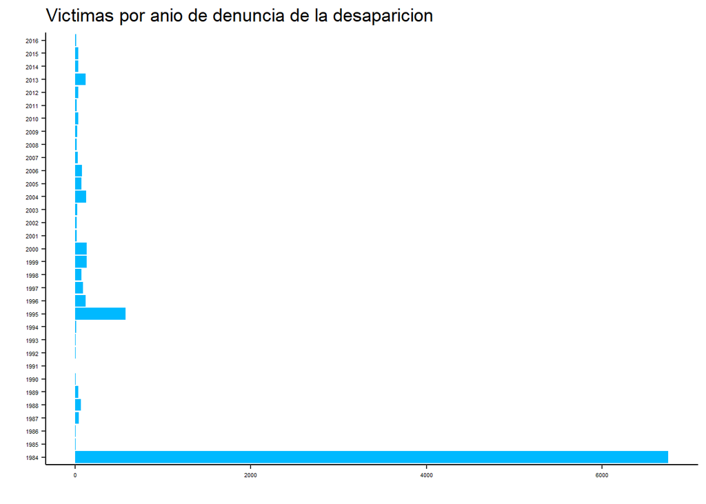

```r
#Graficamos
ggplot(tablas[[6]]) +
 aes(x = anio_denuncia, y = N) +
 geom_col(fill = "#00B9FF") +
 labs(x = " ",
      y = " ",
      title = "Victimas por anio de denuncia de la desaparicion") +
 coord_flip() +
 theme_classic() +
  theme(axis.text = element_text(size =4, color ="black"))
```

### 0.3.2 Edad

```r
victimas %>%
  summarise(media = mean(edad_al_momento_del_hecho_numerico,na.rm = TRUE),
            mediana = median(edad_al_momento_del_hecho_numerico,na.rm = TRUE),
            desvio = sd(edad_al_momento_del_hecho_numerico,na.rm = TRUE)) %>% gt::gt(caption = "Promedio, mediana y desvío estandar de la edad de las victimas de la represión ilegal")
```

Promedio, mediana y desvío estandar de la edad de las victimas de la represión ilegal

| media | mediana | desvio |
| --- | --- | --- |
| 28.08264 | 26 | 9.549192 |

La mediana de edad de las personas desaparecidas en la última dictadura es de 26 años y el promedio es de 28 años, con un desvío de 9.54 años. La amplitud de edad va de 0 años a 81 como se ve puede apreciar a continuación

```r
#valor maximo y valor minimo
kableExtra::kable(quantile(victimas$edad_al_momento_del_hecho_numerico, na.rm = TRUE),caption = "Tabla 2: Edad por cuantiles")
```

Tabla 2: Edad por cuantiles

|  | x |
| --- | --- |
| 0% | 0 |
| 25% | 22 |
| 50% | 26 |
| 75% | 31 |
| 100% | 81 |

### 0.3.3 Nacionalidad de los/las desaparecidos/as

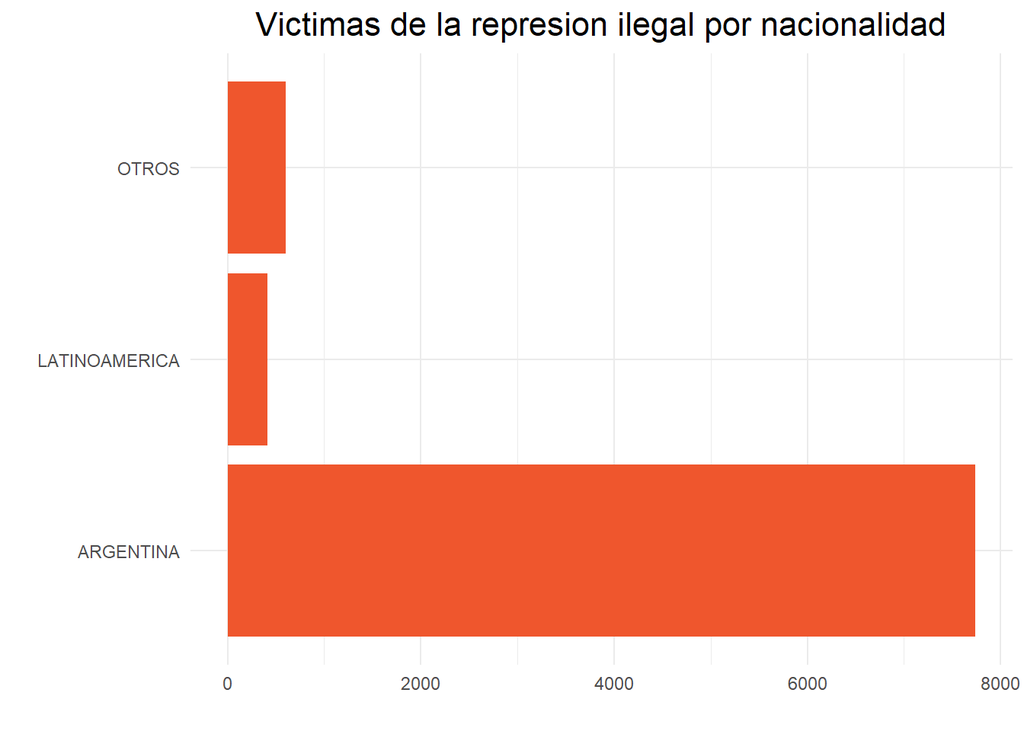

```r
ggplot(tablas[[2]]) +
  aes(x = pais_arg, y = N) +
  geom_col(fill = "#EF562D") +
  labs(
    title = "Victimas de la represion ilegal por nacionalidad"
  ) +
  coord_flip() +
  ylab(" ")+
  xlab(" ")+
  theme_minimal() +
  theme(plot.title = element_text(size = 16L, hjust = 0.5))
```

En relación a este punto, se observa en la *Tabla 2* que la mayoría de las victimas fueron de nacionalidad argentina con gran preponderancia de los paises limitrofes y NAs.

```r
gt::gt(tablas[[1]], caption = "Tabla 2: Victimas de la represión ilegal por pais de nacimiento")
```

Tabla 2: Victimas de la represión ilegal por pais de nacimiento

| pais_nacimiento | N |
| --- | --- |
| ARGENTINA | 7736 |
| sin datos | 389 |
| URUGUAY | 152 |
| PARAGUAY | 87 |
| CHILE | 86 |
| ESPAÑA | 62 |
| ITALIA | 57 |
| dato resguardado | 53 |
| BOLIVIA | 39 |
| PERU | 24 |
| BRASIL | 11 |
| FRANCIA | 9 |
| COLOMBIA | 5 |
| ESTADOS UNIDOS | 4 |
| POLONIA | 4 |
| ALEMANIA | 3 |
| AUSTRIA | 3 |
| VENEZUELA | 3 |
| CHECOESLOVAQUIA | 2 |
| CUBA | 2 |
| MEXICO | 2 |
| RUMANIA | 2 |
| SUIZA | 2 |
| YUGOESLAVIA | 2 |
| BELGICA | 1 |
| ESCOCIA | 1 |
| FINLANDIA | 1 |
| GRECIA | 1 |
| GUATEMALA | 1 |
| HUNGRIA | 1 |
| INGLATERRA | 1 |
| JAPON | 1 |
| LIBANO | 1 |
| LIBIA | 1 |
| LITUANIA | 1 |
| MARRUECOS | 1 |
| PORTUGAL | 1 |
| RUSIA | 1 |

### 0.3.4 Provincia

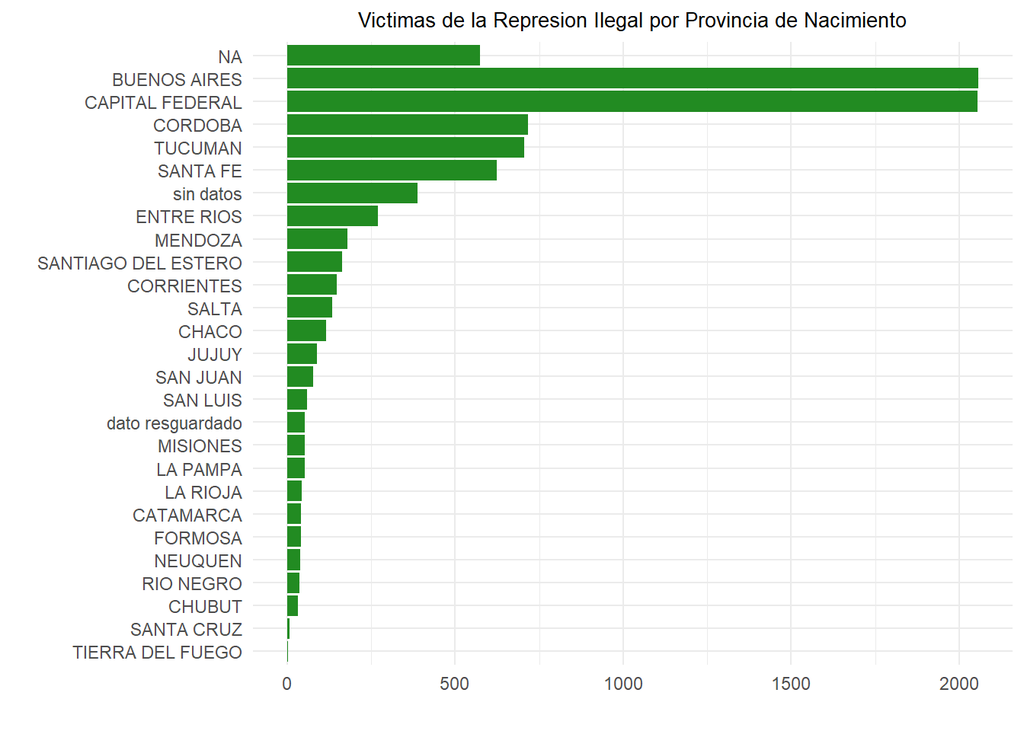

```r
ggplot(tablas[[3]]) +
  aes(x = reorder(provincia_nacimiento,N), y = N) +
  geom_col(fill = "#228B22") +
  labs(
    title = "Victimas de la Represion Ilegal por Provincia de Nacimiento"
  ) +
  ylab(" ")+
  xlab(" ")+
  coord_flip() +
  theme_minimal() +
  theme(plot.title = element_text(size = 10L, hjust = 0.5))
```

Se observa que hay mayor frecuencia de desaparecidos oriundos de Buenos Aires y Capital Federal

### 0.3.5 Embarazo

```r
gt::gt(tablas[[4]], caption = "Tabla 2: Victimas de la represión ilegal por embarazo")
```

Tabla 2: Victimas de la represión ilegal por embarazo

| embarazo | N |
| --- | --- |
| NA | 8418 |
| EMBARAZADA | 284 |
| EMBARAZADA / HIJA NACIDA EN CAUTIVERIO LOCALIZADA | 19 |
| EMBARAZADA / HIJO NACIDO EN CAUTIVERIO LOCALIZADO | 17 |
| EMBARAZADA / HIJA NACIDA EN CAUTIVERIO ENTREGADA A LA FAMILIA | 5 |
| EMBARAZADA en lugar de reclusión | 4 |
| EMBARAZADA / DA A LUZ A SU HIJO SIN VIDA | 2 |
| EMBARAZADA (aparentemente")" | 1 |
| EMBARAZADA (mellizos) / HIJA NACIDA EN CAUTIVERIO LOCALIZADA | 1 |
| EMBARAZADA (mellizos) / HIJOS NACIDOS EN CAUTIVERIO LOCALIZADOS | 1 |
| EMBARAZADA (probablemente")" | 1 |

En relación a las personas embarazadas, en 335 casos la victima era una persona cursando un embarazo

### 0.3.6 Tipificación RUVTE

```r
gt::gt(tablas[[5]], caption = "Tabla 2: Victimas de la represión ilegal por tipificación ruvte")
```

Tabla 2: Victimas de la represión ilegal por tipificación ruvte

| tipificacion_ruvte | N |
| --- | --- |
| DESAPARICION FORZADA | 6054 |
| ASESINATO | 1506 |
| DESAPARICION FORZADA / EXHUMADOS E IDENTIFICADOS SUS RESTOS | 515 |
| DESAPARICION FORZADA / CON INFORMACION SOBRE EL DECESO (NO PROBADO) | 255 |
| DESAPARICION FORZADA / PROBADO EL DECESO | 162 |
| ASESINATO / EXHUMADOS E IDENTIFICADOS SUS RESTOS | 33 |
| ASESINATO / PROCEDENTE POR APLICACION DE ART. 6º DE LA LEY 24.823 | 31 |
| NIÑA DESAPARECIDA" LOCALIZADA / RESTITUIDA" | 24 |
| NIÑA NACIDA EN CAUTIVERIO LOCALIZADA / RESTITUIDA | 21 |
| NIÑO DESAPARECIDO" LOCALIZADO / RESTITUIDO" | 20 |
| NIÑO NACIDO EN CAUTIVERIO LOCALIZADO / RESTITUIDO | 20 |
| ASESINATO / PROBADO EN CAUSA JUDICIAL | 18 |
| ASESINATO / INVESTIGADO EN CAUSA JUDICIAL | 9 |
| NIÑO DESAPARECIDO" ENTREGADO A SU FAMILIA" | 9 |
| DESAPARICION FORZADA / EN INVESTIGACION | 8 |
| NIÑO DESAPARECIDO" LOCALIZADO" | 8 |
| NIÑA DESAPARECIDA" ENTREGADA A SU FAMILIA" | 7 |
| DESAPARICION FORZADA / A DETERMINAR TIPIFICACION | 5 |
| DESAPARICION FORZADA / INVESTIGADO EN CAUSA JUDICIAL | 5 |
| NIÑA DESAPARECIDA" JUNTO A PADRES O ALLEGADOS" | 5 |
| NIÑA DESAPARECIDA" LOCALIZADA" | 5 |
| NIÑA NACIDA EN CAUTIVERIO ENTREGADA A SU FAMILIA | 5 |
| NIÑO ASESINADO JUNTO A PADRES O ALLEGADOS | 4 |
| NIÑO DESAPARECIDO" JUNTO A PADRES O ALLEGADOS" | 4 |
| NIÑO DESAPARECIDO" ENTREGADO A SU FAMILIA POR AUTORIDAD JUDICIAL" | 3 |
| ASESINATO / PROCEDENTE POR RESOLUCION JUDICIAL | 2 |
| DESAPARICION FORZADA / PROBADO EN CAUSA JUDICIAL | 2 |
| NIÑA ASESINADA JUNTO A PADRES O ALLEGADOS | 2 |
| NIÑO FALLECIDO POR TRATO NEGLIGENTE | 2 |
| ASESINATO / PROCEDENTE POR ACTO ADMINISTRATIVO EN APLICACION DE ART. 6º DE LA LEY 24.823 | 1 |
| DESAPARICION FORZADA (NIÑA) / EXHUMADOS E IDENTIFICADOS SUS RESTOS | 1 |
| DESAPARICION FORZADA (NIÑO) / EXHUMADOS E IDENTIFICADOS SUS RESTOS | 1 |
| NIÑA DESAPARECIDA" ENTREGADA A SU FAMILIA POR AUTORIDAD JUDICIAL" | 1 |
| NIÑA NACIDA EN CAUTIVERIO DESAPARECIDA"" | 1 |
| NIÑO ASESINADO JUNTO A PADRES O ALLEGADOS / EXHUMADOS E IDENTIFICADOS SUS RESTOS | 1 |
| NIÑO DESAPARECIDO" LIBERADO" | 1 |
| NIÑO NACIDO EN CAUTIVERIO ENTREGADO A SU FAMILIA | 1 |
| NIÑO NACIDO EN CAUTIVERIO ENTREGADO A SU FAMILIA POR AUTORIDAD JUDICIAL | 1 |

Las categorías de la variable “tipificacion” no se encuentran limpias, por lo que no es posible realizar filtros. No obstante, resulta interesante para futuros trabajos

En síntesis, los datos muestran que hubo más victimas nacidas en Buenos Aires, Capital y Córdoba que en otras provincias. No se encuentra registros separados por género, por lo que no se pudo calcular la proporción de personas embarazadas.

## 0.4 Hipótesis

*Existe mayor cantidad de desapariciones en la ciudad de buenos aires y provincia de buenos aires porque son los Estados que poseen mayor población*

### 0.4.1 Análisis

Se utilizará para contrastar la hipótesis datos extraidos del Censo de 1980. La fuente de datos es el Instituto Nacional de Estadisticas y Censos ([INDEC](https://www.indec.gob.ar/indec/web/Nivel4-Tema-2-41-164))

```r
#leemos el archivo del censo 1980
censo_1980 <- read_excel("censo_1980.xlsx")
#pasamos a mayúscula los nombres de las provincias
censo_1980$Provincia <- toupper(censo_1980$Provincia)

#creamos una frecuencia de la cantidad de victimas por provincia
frecuencia_provincia <- victimas %>%
  group_by(provincia_nacimiento) %>%
  summarise(N = n()) %>%
  rename(Provincia = provincia_nacimiento)


#consolidamos las bases

freq_prov_cons <- full_join(x = frecuencia_provincia, y = censo_1980, by = "Provincia")

#Unimos los NAs con los "sin datos"
freq_prov_cons <- freq_prov_cons %>%
  mutate(Provincia = ifelse(is.na(Provincia),"sin datos", Provincia),
         porcentaje_pob_des = round(((N/Poblacion)*100),3))%>%
  arrange(desc(porcentaje_pob_des))
```

En principio podemos observar que en `frecuencia_provincia` existen 575 NAs en provincia, 389 “sin datos” y, 53 datos resguardados. Lo que nos da un total de 1017 datos faltantes.

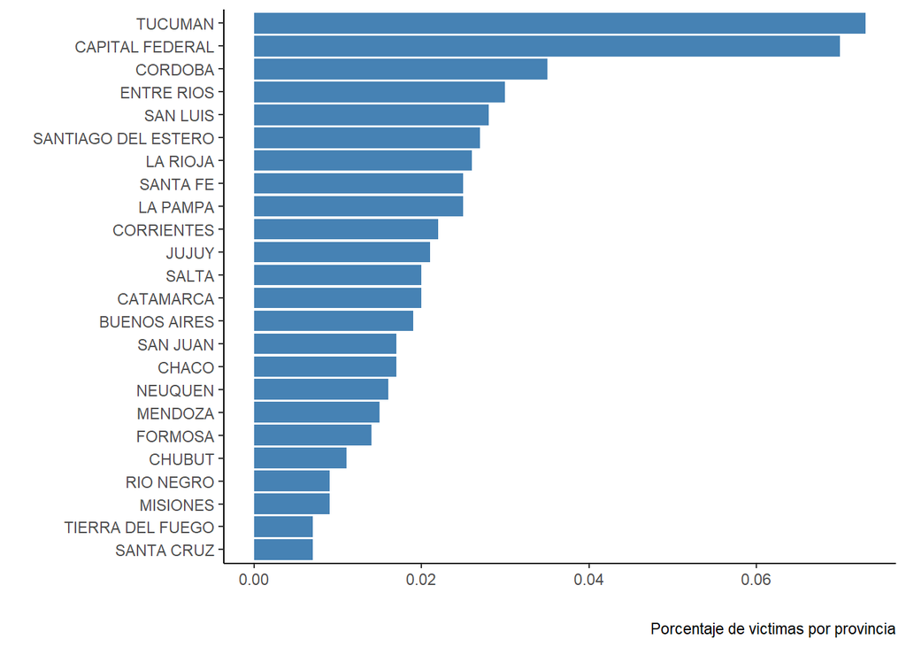

```r
#Graficamos

freq_prov_cons %>%
  filter(!is.na(Poblacion)) %>%
  ggplot(aes(x = reorder(Provincia,porcentaje_pob_des), y = porcentaje_pob_des)) +
  geom_col(fill = "#4682B4") +
  labs(caption = "Porcentaje de victimas por provincia") +
  ylab(" ") +
  xlab(" ") +
  coord_flip() +
  theme_classic()
```

### 0.4.2 Consideraciones finales

En relación a nuestra hipótesis, podemos confirmar parte de la misma, dado que se observa que en terminos proporcionales - teniendo en cuenta la población total de cada una de las provincias- es *Tucumán* la provincia con mayor porcentaje de victimas y, no así la Provincia de Buenos Aires. Vale aclarar que numerosos trabajos, afirman que la Provincia de Tucumán fue [“el tubo de ensayo del genocidio, que tuvo por objetivo el terror y el disciplinamiento de la población a partir de secuestros y torturas”.](https://escuelitadefamailla.org/el-genocidio-comenzo-en-tucuman-con-el-operativo-independencia/#:~:text=Tucum%C3%A1n%20fue%20el%20tubo%20de,y%20edificios%20p%C3%BAblicos%20y%20privados.) Por último, se hace notar que Capital Federal, si bien es uno de los distritos mas poblados, posee en terminos proporcionales el segundo lugar.

### 0.4.3 NUNCA MÁS

Nube de palabras con los `apodos` de las `victimas`

```r
apodos <- presentes::apodos

presentes <- data.frame(apodos$apodo)

for (j in 1:100) {
    presentes[j, ] <- c("PRESENTES")
}



presentes <- presentes %>%
  select(apodos.apodo) %>%
  count(apodos.apodo, sort = TRUE)


wordcloud2::wordcloud2(presentes , size = 1, minRotation = -pi/6, maxRotation = -pi/6,
                  color = "skyblue", backgroundColor = "white")
```

[interactive chart not shown]